# Week 1 Blog - 9/15/22

Welcome to the Week 1 blog! This week's blog is mostly focused on setting up the blog with Github pages, as well as working with election data for the first time. Nevertheless, I am going to point out a couple of observations.

## Republican Two Party Voteshare in 2012 by State

First, we see here that in 2012 there are a number of purple states, such as Nevada, North Carolina, and Iowa. Even though all of these but Nevada would vote for Romney in the presidential election, we see that they are very close in the congressional election, pointing out that the models needed to analyze these two different types of races differ.

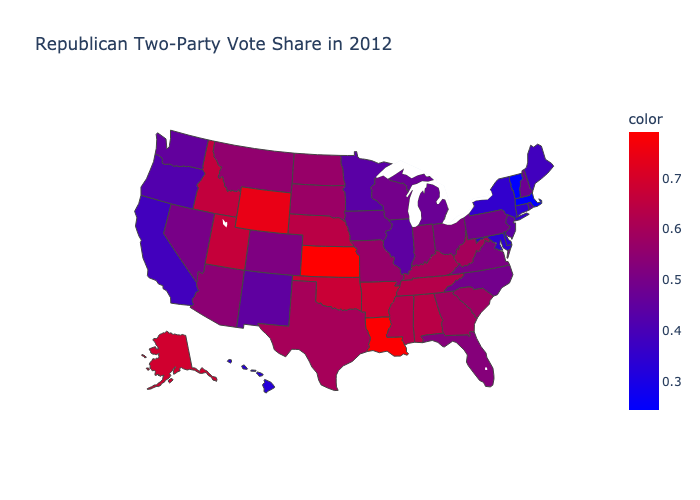

# Voting by State and District Level in 2014

Moving to a midterm election, we see that the entire country has become more red, leading to the traditional wisdom that midterms turn out Republican voters more. However, with changing preferences among those who are likely to show up to midterms (highly engaged voters), these may skew more towards Democrats now (backed up by the 2018 experience). Also notably, not all solid blue states are identical -- MA had an 82% vote share for democrats while CA had only 62%. This shows that using simple "solid D" vs "lean D" misses wide degrees of nuance that may be helpful for prpjecting midterm outcomes.

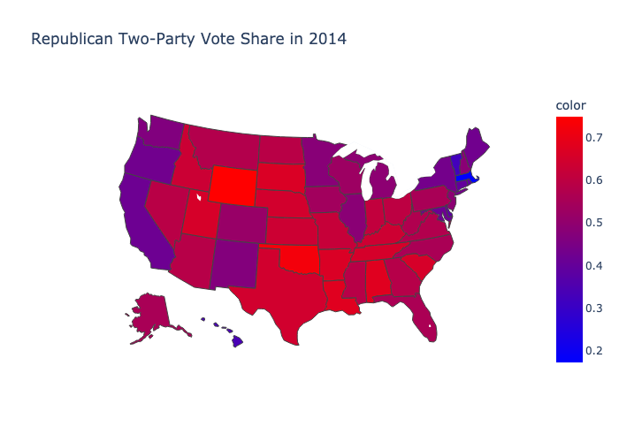

Finally, we see here that district-by-district level, some of the bluest districts reside within red states. This shows that imputing a state's political leanings down to the district level is highly flawed, particularly in highly gerrymandered states where voters of the minority party may be packed into one district. Using statewide data would be inappropriate for these districts.

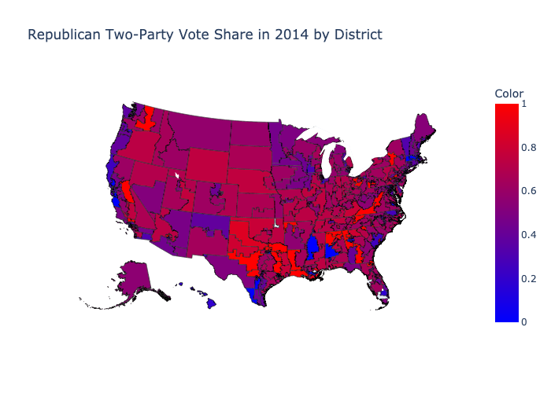

Some notes for future blogs:

- The maps states don't have labels. In the Python notebook they have labels on hover, but to get this to work on the Rmd blog, I needed to save to images and lose the labels.
- In the future, I will work on creating interactive maps with GGPlot/R, but for this week to understand the data I used Python which I am more comfortable with.